# Ch04 Confusion and Lift

Bruce Hartman

University of St. Francis

2026-09-12 Revised 2026-10-22T20:18:59

Abstract

We explain the lift metric as used in classification. Classification is treated the textbook Chapter 4, but lift is not mentioned in the text.

# Introduction

We present the concept of Lift prevalent in marketing, and its relation to the Confusion Matrix. First you should be familiar with the analysis in tidy Classification and Confusion.

# Packages

Loading the standard packages for this course:

# Data

```r
data(Default)
Default %>% skim
```

```
── Data Summary ────────────────────────
                           Values
Name                       Piped data
Number of rows             10000
Number of columns          4
_______________________
Column type frequency:
  factor                   2
  numeric                  2
________________________
Group variables            None
```

|  | skim_variable | n_missing | complete_rate | ordered | n_unique | top_counts |
| --- | --- | --- | --- | --- | --- | --- |
| 1 | default | 0 | 1 | FALSE | 2 | No: 9667, Yes: 333 |
| 2 | student | 0 | 1 | FALSE | 2 | No: 7056, Yes: 2944 |

|  | skim_variable | n_missing | complete_rate | mean | sd | p0 | p25 | p50 | p75 | p100 | hist |
| --- | --- | --- | --- | --- | --- | --- | --- | --- | --- | --- | --- |
| 1 | balance | 0 | 1 | 835.3749 | 483.715 | 0.0000 | 481.7311 | 823.637 | 1166.308 | 2654.323 | ▆▇▅▁▁ |
| 2 | income | 0 | 1 | 33516.9819 | 13336.640 | 771.9677 | 21340.4629 | 34552.645 | 43807.729 | 73554.233 | ▂▇▇▅▁ |

# Logistic Regresssion

# Validation Datasets

`tidymodels` provides the best way to do this.

```r
# takes first half of data
split <- initial_time_split(Default, prop = .5)
train_data <- training(split)
test_data  <- testing(split)
dim(train_data)
```

```
[1] 5000    4
```

```r
dim(test_data)
```

```
[1] 5000    4
```

```r
# contrasts for factors
contrasts(Default$default)
```

```
    Yes-No
No    -0.5
Yes    0.5
```

```r
contrasts(Default$student)
```

```
    Yes-No
No    -0.5
Yes    0.5
```

```r
D.train=train_data
D.test=test_data
```

# Model

Specify the model structure using `tidymodels`. This can be reused each time we run logistic regression.

```r
log_spec <- logistic_reg() %>%
  set_engine("glm") %>%
  set_mode("classification")
```

# Train

Now we can ‘train’ logistic regression on the train part of the dataset. Use the special function to display and color the significant variables in a `gt` table.

```r
glm.logit <- log_spec %>%
  fit(default ~ balance + student, data = D.train)

glm.logit %>% extract_fit_engine() %>% summary
```

```
Call:
stats::glm(formula = default ~ balance + student, family = stats::binomial,
    data = data)

Coefficients:
                Estimate Std. Error z value Pr(>|z|)
(Intercept)   -1.127e+01  5.470e-01 -20.607  < 2e-16 ***
balance        5.899e-03  3.302e-04  17.868  < 2e-16 ***
studentYes-No -8.402e-01  2.096e-01  -4.009  6.1e-05 ***
---
Signif. codes:  0 ‘***’ 0.001 ‘**’ 0.01 ‘*’ 0.05 ‘.’ 0.1 ‘ ’ 1

(Dispersion parameter for binomial family taken to be 1)

    Null deviance: 1517.14  on 4999  degrees of freedom
Residual deviance:  796.89  on 4997  degrees of freedom
AIC: 802.89

Number of Fisher Scoring iterations: 8
```

```r
glm.logit %>% glance %>% gt_add_significance() %>%
  tab_header(title="glance Overall")
```

glance Overall

| null.deviance | df.null | logLik | AIC | BIC | deviance | df.residual | nobs |
| --- | --- | --- | --- | --- | --- | --- | --- |
| 1,517.1448 | 4,999.0000 | −398.4445 | 802.8891 | 822.4407 | 796.8891 | 4,997.0000 | 5,000.0000 |

```r
glm.logit %>% tidy %>% gt_add_significance() %>%
  tab_header(title="tidy Coefficients")
```

tidy Coefficients

| term | estimate | std.error | statistic | p.value |
| --- | --- | --- | --- | --- |
| (Intercept) | −11.2718 | 0.5470 | −20.6069 | 0.0000 |
| balance | 0.0059 | 0.0003 | 17.8679 | 0.0000 |
| studentYes-No | −0.8402 | 0.2096 | −4.0090 | 0.0001 |

# Predictions

Next we make predictions for the `D.test` data using the model we developed, using the `predict()` function in R, with the “response” type.

These predictions are probabilities, and we turn them into “No”/“Yes” values by assuming that the prior probability in `D.train` is the threshold. They aren’t equally likely. But for simplicity we’ll assume they are, and use a threshold of .5.

```r
# probabilities needed for later
probs <- predict(glm.logit, new_data = D.test,
                 type = "prob")

preds.class.5 = case_when(
  probs$.pred_Yes >.5 ~ "Yes",
  .default = "No") %>% factor
preds.class.5 %>% table
```

```
.
  No  Yes
4920   80
```

## Confusion matrix

First we make a dataframe that has all we need for classification analysis, containing the true classes, the estimated or predicted classes, and the probabilities of the two classes.

```r
t = data.frame(truth=D.test$default,
               estimate = preds.class.5, probs)
t %>% glimpse
```

```
Rows: 5,000
Columns: 4
$ truth     <fct> No, No, No, No, No, No, No, No, No, No, No, No, No, No, Yes,…
$ estimate  <fct> No, No, No, No, No, No, No, No, No, No, No, No, No, No, No, …
$ .pred_No  <dbl> 0.9999544, 0.9992009, 0.9992905, 0.9741600, 0.9998668, 0.999…
$ .pred_Yes <dbl> 4.562602e-05, 7.990616e-04, 7.095075e-04, 2.584004e-02, 1.33…
```

We compare the results by making a confusion matrix with the “states of nature” (truth, from the dataset!) in the columns and the predictions in the rows. The columns are the values of default in the test dataset; the rows are the values of `preds`, the predictions, made by the model. Each cell of the table tells us how many observations fell into each category.

```r
cmlog = t %>% conf_mat(truth, estimate)
cmlog
```

```
          Truth
Prediction   No  Yes
       No  4816  104
       Yes   26   54
```

# Metrics

```r
cmlog %>% summary
```

| .metric | .estimator | .estimate |
| --- | --- | --- |
| accuracy | binary | 0.9740000 |
| kap | binary | 0.4419260 |
| sens | binary | 0.9946303 |
| spec | binary | 0.3417722 |
| ppv | binary | 0.9788618 |
| npv | binary | 0.6750000 |
| mcc | binary | 0.4689997 |
| j_index | binary | 0.3364025 |
| bal_accuracy | binary | 0.6682012 |
| detection_prevalence | binary | 0.9840000 |

[output cut: 3 more lines]

# Lift Definition

Remember the layout of the confusion matrix; we designate each cell by a letter:

[output not shown]

# Math of Lift

The definition of Lift is the ratio of the actual probability of the upper left cell, $\Pr(\cal{Q} \& \cal{R})$, to what it would be if $\cal{Q}$ and $\cal{R}$ were independent events; that is, predictions and responses were uncorrelated. The probability of that cell if A and B are independent is $\Pr(\cal{Q})* \Pr(\cal{R})$. So we have the following.

$$\textrm{Lift}
=\frac{\Pr(pred=="No"
\wedge\ default=="No")}{\Pr(pred=="No")
\Pr(default=="No")}$$
$$\textrm{Lift} = \frac{\frac{4816}{4816+104+26+54}
}{ \bigg(
\frac{4816+104}{4816+104+26+54}\frac{4816+26}{4816+104+26+54}\bigg)
}$$
**SINCE ALL DENOMINATORS ARE THE SAME**,

$$\textrm{Lift} = \frac{4816 *
(4816+104+26+54) }{ (4816+104) * (4816+26) } =
\frac{A(A+B+C+D)}{(A+B)(A+C)}$$

```r
lift = (4816)*(4816+104+26+54) /( (4816+104) * (4816+26) )
lift
```

```
[1] 1.010803
```

This calculation tells us that the prediction algorithm has lift of 1.01. It is 1.01 times better than if the prediction and the default were statistically independent. In other words, not much.

How much better (or worse) than random independence are we doing by predicting? Lift answers that question.

Lift compares the actual $\Pr(\cal{Q} \wedge \cal{R})$ with the independent events $\Pr(\cal{Q})\Pr(\cal{R})$ by a ratio.

# Lift and Confusion Matrix

Lift can be calculated from the confusion matrix.

| Probability | Calculation | R Calculation | Metric |  |
| --- | --- | --- | --- | --- |
| $Prob(A \wedge B)$ | 4816/(4816+104+26+54) | 0.9632 | *Detection Rate* |  |
| $Prob(A) = Prob(pred="No")$ | (4816+104)/(4816+104+26+54) | 0.984 | `detection_prevalence` |  |
| $Prob(B) = Prob(default="No")$ | (4816+26)/(4816+104+26+54) | 0.9684 | *Prevalence*, *No Information Rate* |  |

$$\textrm{Lift} =
\frac{\Pr(A\&B)}{\Pr(A)\Pr(B)} = \frac{Detection Rate}{(Detection
Prevalence)(Prevalence)} =
\frac{recall*precision}{detection\_rate}$$
Some numbers (`precision, recall`) are available in the confusion matrix. Since `detection_rate` is not calculated in `yardstick` we have a small function in `detection_rate.R` to do it.

Here we get the metrics required from the standard metrics and our function.

```r
L = bind_rows(
  cmlog %>% summary %>% select(.metric, .estimate) %>%
  filter(.metric %in% c("precision", "recall")),

  tibble(.metric = "detection_rate",
         .estimate = detectionrate(cmlog))
            ) %>%
  pivot_wider(values_from=.estimate,
              names_from = .metric)
L
```

| precision | recall | detection_rate |
| --- | --- | --- |
| 0.9788618 | 0.9946303 | 0.9632 |

# Lift

Lift can be calculated from the `lift_metrics` using `recall`, `precision`, and `detection_rate`.

```r
L %>% mutate(Lift = recall*precision/detection_rate)
```

| precision | recall | detection_rate | Lift |
| --- | --- | --- | --- |
| 0.9788618 | 0.9946303 | 0.9632 | 1.010803 |

# Lift Curve

A lift curve plots lift against different thresholds. Here the percent tested ranges from 0 to 100%.

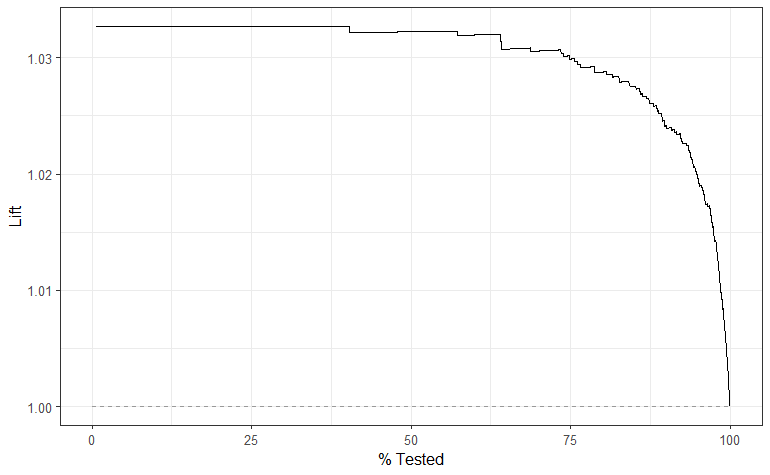

```r
# t has the classes and the probabilities of No, the base case
t %>% lift_curve(truth, .pred_No) %>% autoplot()
```

# Gain Curve

The motivation behind cumulative gain and lift charts is as a visual method to determine the effectiveness of a model when compared to the results one might expect without a model. As an example, without a model, if you were to advertise to a random 10% of your customer base, then you might expect to capture 10% of the of the total number of positive responses had you advertised to your entire customer base. Given a model that predicts which customers are more likely to respond, the hope is that you can more accurately target 10% of your customer base and capture >10% of the total number of positive responses.

The calculation to construct gain curves is as follows:

- truth and estimate are placed in descending order by the estimate values (estimate here is a single column supplied in …).
- The cumulative number of samples with true results relative to the entire number of true results are found. This is the y-axis in a gain chart.

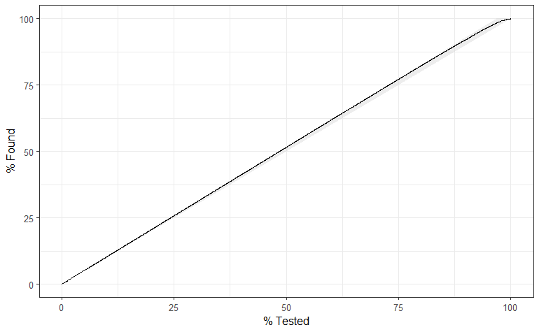

```r
t %>% gain_curve(truth, .pred_No) %>% autoplot
```

Virtually all found are “No”, so the line shows we found all of them when we tested.

# pr Curve

Computes the `precision` at every unique value of the probability column, as a function of `recall`.

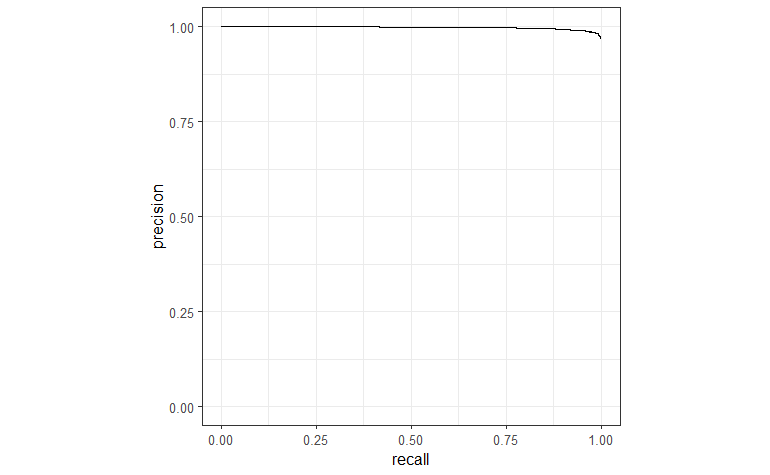

```r
t %>% pr_curve(truth, .pred_No) %>% autoplot
```

# ROC curve

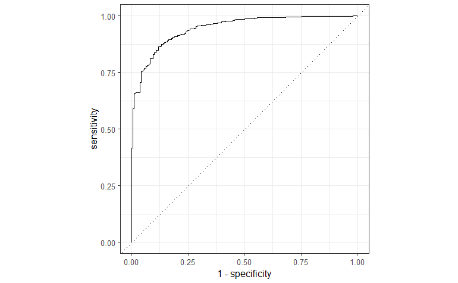

```r
t %>% roc_curve(truth, .pred_No) %>% autoplot
```

# Application

We will apply the methods to a real marketing dataset from ISLR2, `OJ`. The data contains 1070 purchases where the customer either purchased Citrus Hill or Minute Maid Orange Juice. A number of characteristics of the customer and product are recorded.

The balance of the dataset is more even than `Default`, but not too even. It might show the various metrics off better.

The target is `Purchase` with levels the two brands of juice. Drivers are numeric, except for a factor that identifies a particular store, `Store7`.

## Data

```r
data(OJ)
OJ
```

|  | Purchase | WeekofPurchase | StoreID | PriceCH | PriceMM | DiscCH | DiscMM | SpecialCH | SpecialMM | LoyalCH | SalePriceMM | SalePriceCH | PriceDiff | Store7 | PctDiscMM | PctDiscCH | ListPriceDiff | STORE |
| --- | --- | --- | --- | --- | --- | --- | --- | --- | --- | --- | --- | --- | --- | --- | --- | --- | --- | --- |
| 1 | CH | 237 | 1 | 1.75 | 1.99 | 0.00 | 0.00 | 0 | 0 | 0.500000 | 1.99 | 1.75 | 0.24 | No | 0.000000 | 0.000000 | 0.24 | 1 |
| 2 | CH | 239 | 1 | 1.75 | 1.99 | 0.00 | 0.30 | 0 | 1 | 0.600000 | 1.69 | 1.75 | -0.06 | No | 0.150754 | 0.000000 | 0.24 | 1 |
| 3 | CH | 245 | 1 | 1.86 | 2.09 | 0.17 | 0.00 | 0 | 0 | 0.680000 | 2.09 | 1.69 | 0.40 | No | 0.000000 | 0.091398 | 0.23 | 1 |
| 4 | MM | 227 | 1 | 1.69 | 1.69 | 0.00 | 0.00 | 0 | 0 | 0.400000 | 1.69 | 1.69 | 0.00 | No | 0.000000 | 0.000000 | 0.00 | 1 |
| 5 | CH | 228 | 7 | 1.69 | 1.69 | 0.00 | 0.00 | 0 | 0 | 0.956535 | 1.69 | 1.69 | 0.00 | Yes | 0.000000 | 0.000000 | 0.00 | 0 |
| 6 | CH | 230 | 7 | 1.69 | 1.99 | 0.00 | 0.00 | 0 | 1 | 0.965228 | 1.99 | 1.69 | 0.30 | Yes | 0.000000 | 0.000000 | 0.30 | 0 |
| 7 | CH | 232 | 7 | 1.69 | 1.99 | 0.00 | 0.40 | 1 | 1 | 0.972182 | 1.59 | 1.69 | -0.10 | Yes | 0.201005 | 0.000000 | 0.30 | 0 |
| 8 | CH | 234 | 7 | 1.75 | 1.99 | 0.00 | 0.40 | 1 | 0 | 0.977746 | 1.59 | 1.75 | -0.16 | Yes | 0.201005 | 0.000000 | 0.24 | 0 |
| 9 | CH | 235 | 7 | 1.75 | 1.99 | 0.00 | 0.40 | 0 | 0 | 0.982197 | 1.59 | 1.75 | -0.16 | Yes | 0.201005 | 0.000000 | 0.24 | 0 |
| 10 | CH | 238 | 7 | 1.75 | 1.99 | 0.00 | 0.40 | 0 | 0 | 0.985757 | 1.59 | 1.75 | -0.16 | Yes | 0.201005 | 0.000000 | 0.24 | 0 |

[output cut: 990 more lines]

```r
OJ %>% skim
```

```
── Data Summary ────────────────────────
                           Values
Name                       Piped data
Number of rows             1070
Number of columns          18
_______________________
Column type frequency:
  factor                   2
  numeric                  16
________________________
Group variables            None
```

|  | skim_variable | n_missing | complete_rate | ordered | n_unique | top_counts |
| --- | --- | --- | --- | --- | --- | --- |
| 1 | Purchase | 0 | 1 | FALSE | 2 | CH: 653, MM: 417 |
| 2 | Store7 | 0 | 1 | FALSE | 2 | No: 714, Yes: 356 |

|  | skim_variable | n_missing | complete_rate | mean | sd | p0 | p25 | p50 | p75 | p100 | hist |
| --- | --- | --- | --- | --- | --- | --- | --- | --- | --- | --- | --- |
| 1 | WeekofPurchase | 0 | 1 | 254.38130841 | 15.5582861 | 2.27e+02 | 240.0000000 | 257.00 | 268.0000000 | 278.000000 | ▆▅▅▇▇ |
| 2 | StoreID | 0 | 1 | 3.95981308 | 2.3089835 | 1.00e+00 | 2.0000000 | 3.00 | 7.0000000 | 7.000000 | ▇▅▃▁▇ |
| 3 | PriceCH | 0 | 1 | 1.86742056 | 0.1019698 | 1.69e+00 | 1.7900000 | 1.86 | 1.9900000 | 2.090000 | ▅▂▇▆▁ |
| 4 | PriceMM | 0 | 1 | 2.08541121 | 0.1343855 | 1.69e+00 | 1.9900000 | 2.09 | 2.1800000 | 2.290000 | ▂▁▃▇▆ |
| 5 | DiscCH | 0 | 1 | 0.05185981 | 0.1174742 | 0.00e+00 | 0.0000000 | 0.00 | 0.0000000 | 0.500000 | ▇▁▁▁▁ |
| 6 | DiscMM | 0 | 1 | 0.12336449 | 0.2138337 | 0.00e+00 | 0.0000000 | 0.00 | 0.2300000 | 0.800000 | ▇▁▂▁▁ |
| 7 | SpecialCH | 0 | 1 | 0.14766355 | 0.3549321 | 0.00e+00 | 0.0000000 | 0.00 | 0.0000000 | 1.000000 | ▇▁▁▁▂ |
| 8 | SpecialMM | 0 | 1 | 0.16168224 | 0.3683312 | 0.00e+00 | 0.0000000 | 0.00 | 0.0000000 | 1.000000 | ▇▁▁▁▂ |
| 9 | LoyalCH | 0 | 1 | 0.56578233 | 0.3078425 | 1.10e-05 | 0.3252572 | 0.60 | 0.8508728 | 0.999947 | ▅▃▆▆▇ |
| 10 | SalePriceMM | 0 | 1 | 1.96204673 | 0.2526974 | 1.19e+00 | 1.6900000 | 2.09 | 2.1300000 | 2.290000 | ▁▂▂▂▇ |

[output cut: 6 more lines]

Both `Store7` and `Purchase` are fairly balanced.

## Prep

We will split randomly with a training set 80% of the data.

```r
# takes first half of data
split <- initial_split(OJ, prop = .8)
train_data <- training(split)
test_data  <- testing(split)
dim(train_data)
```

```
[1] 856  18
```

```r
dim(test_data)
```

```
[1] 214  18
```

```r
# contrasts for factors
contrasts(OJ$Purchase)
```

```
   MM-CH
CH  -0.5
MM   0.5
```

```r
contrasts(OJ$Store7)
```

```
    Yes-No
No    -0.5
Yes    0.5
```

## Train

```r
OJ.logit <- log_spec %>%
  fit(Purchase ~ ., data = train_data)

OJ.logit %>% extract_fit_engine() %>% summary
```

```
Call:
stats::glm(formula = Purchase ~ ., family = stats::binomial,
    data = data)

Coefficients: (5 not defined because of singularities)
                Estimate Std. Error z value Pr(>|z|)
(Intercept)      4.03563    2.19895   1.835 0.066469 .
WeekofPurchase  -0.01202    0.01189  -1.010 0.312423
StoreID         -0.25592    0.15591  -1.641 0.100701
PriceCH          5.10912    2.04448   2.499 0.012455 *
PriceMM         -3.35579    1.00934  -3.325 0.000885 ***
DiscCH          14.45073   20.33112   0.711 0.477228
DiscMM          28.24007    9.81305   2.878 0.004005 **
SpecialCH        0.40990    0.37697   1.087 0.276877
SpecialMM        0.23268    0.30252   0.769 0.441814
LoyalCH         -5.91972    0.42339 -13.982  < 2e-16 ***
SalePriceMM           NA         NA      NA       NA
SalePriceCH           NA         NA      NA       NA
PriceDiff             NA         NA      NA       NA
Store7Yes-No     0.65424    0.80271   0.815 0.415050
PctDiscMM      -54.50907   20.50812  -2.658 0.007862 **
PctDiscCH      -34.09331   38.47902  -0.886 0.375605
ListPriceDiff         NA         NA      NA       NA
STORE                 NA         NA      NA       NA
---
Signif. codes:  0 ‘***’ 0.001 ‘**’ 0.01 ‘*’ 0.05 ‘.’ 0.1 ‘ ’ 1

(Dispersion parameter for binomial family taken to be 1)

    Null deviance: 1139.50  on 855  degrees of freedom
Residual deviance:  669.51  on 843  degrees of freedom
AIC: 695.51

Number of Fisher Scoring iterations: 5
```

```r
OJ.logit %>% glance %>% gt_add_significance() %>%
  tab_header(title="glance Overall")
```

glance Overall

| null.deviance | df.null | logLik | AIC | BIC | deviance | df.residual | nobs |
| --- | --- | --- | --- | --- | --- | --- | --- |
| 1,139.5043 | 855.0000 | −334.7558 | 695.5115 | 757.2911 | 669.5115 | 843.0000 | 856.0000 |

```r
OJ.logit %>% tidy %>% gt_add_significance() %>%
  tab_header(title="tidy Coefficients")
```

tidy Coefficients

| term | estimate | std.error | statistic | p.value |
| --- | --- | --- | --- | --- |
| (Intercept) | 4.0356 | 2.1990 | 1.8353 | 0.0665 |
| WeekofPurchase | −0.0120 | 0.0119 | −1.0102 | 0.3124 |
| StoreID | −0.2559 | 0.1559 | −1.6415 | 0.1007 |
| PriceCH | 5.1091 | 2.0445 | 2.4990 | 0.0125 |
| PriceMM | −3.3558 | 1.0093 | −3.3247 | 0.0009 |
| DiscCH | 14.4507 | 20.3311 | 0.7108 | 0.4772 |
| DiscMM | 28.2401 | 9.8131 | 2.8778 | 0.0040 |
| SpecialCH | 0.4099 | 0.3770 | 1.0874 | 0.2769 |
| SpecialMM | 0.2327 | 0.3025 | 0.7691 | 0.4418 |
| LoyalCH | −5.9197 | 0.4234 | −13.9817 | 0.0000 |
| SalePriceMM | NA | NA | NA | NA |
| SalePriceCH | NA | NA | NA | NA |
| PriceDiff | NA | NA | NA | NA |
| Store7Yes-No | 0.6542 | 0.8027 | 0.8150 | 0.4150 |
| PctDiscMM | −54.5091 | 20.5081 | −2.6579 | 0.0079 |
| PctDiscCH | −34.0933 | 38.4790 | −0.8860 | 0.3756 |
| ListPriceDiff | NA | NA | NA | NA |
| STORE | NA | NA | NA | NA |

## Predictions

```r
# probabilities needed for later
probs_oj <- predict(OJ.logit, new_data = test_data,
                 type = "prob")
preds.class_oj = case_when(
  probs_oj$.pred_CH >.5 ~ "CH",
  .default = "MM") %>% factor
preds.class_oj %>% table
```

```
.
 CH  MM
129  85
```

## Confusion Matrix

```r
J = data.frame(truth=test_data$Purchase,
               estimate = preds.class_oj, probs_oj)

cmoj = J %>% conf_mat(truth, estimate)
cmoj
```

```
          Truth
Prediction  CH  MM
        CH 114  15
        MM  11  74
```

## Metrics

```r
cmoj %>% summary
```

| .metric | .estimator | .estimate |
| --- | --- | --- |
| accuracy | binary | 0.8785047 |
| kap | binary | 0.7483036 |
| sens | binary | 0.9120000 |
| spec | binary | 0.8314607 |
| ppv | binary | 0.8837209 |
| npv | binary | 0.8705882 |
| mcc | binary | 0.7488653 |
| j_index | binary | 0.7434607 |
| bal_accuracy | binary | 0.8717303 |
| detection_prevalence | binary | 0.6028037 |

[output cut: 3 more lines]

## Metrics for Lift etc

```r
O = bind_rows(
  cmoj %>% summary %>% select(.metric, .estimate) %>%
  filter(.metric %in% c("precision", "recall")),

  tibble(.metric = "detection_rate",
         .estimate = detectionrate(cmoj))
            ) %>%
  pivot_wider(values_from=.estimate,
              names_from = .metric) %>%
  mutate(Lift = recall*precision/detection_rate)
O
```

| precision | recall | detection_rate | Lift |
| --- | --- | --- | --- |
| 0.8837209 | 0.912 | 0.5327103 | 1.51293 |

## Curves

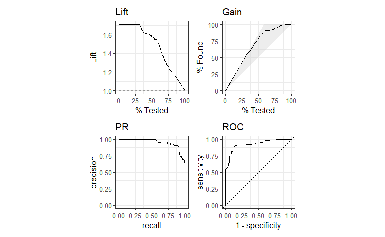

```r
wrap_plots(ncol=2,
J %>% lift_curve(truth, .pred_CH) %>% autoplot() +labs(title="Lift"),
J %>% gain_curve(truth, .pred_CH) %>% autoplot() +labs(title="Gain"),
J %>% pr_curve(truth, .pred_CH) %>% autoplot()  +labs(title="PR"),
J %>% roc_curve(truth, .pred_CH) %>% autoplot() +labs(title="ROC")
)
```

```r
J %>% roc_auc(truth, .pred_CH) %>% select(.metric, .estimate)
```

| .metric | .estimate |
| --- | --- |
| roc_auc | 0.925573 |

# Conclusion

We have learned the meaning of Marketing Lift, and how it is computed using the confusion matrix.

We applied the workflow to the `OJ` dataset to show a marketing application.

# References

1. Lift (data mining). (2022, June 24). In Wikipedia. https://en.wikipedia.org/wiki/Lift_(data_mining)
2. [tidy Classification and Confusion, 2025](https://learn.stfrancis.edu/courses/1192468/files/64978355?wrap=1), available in Canvas Course MBAD640.